# Differential Expression analysis at the top-level cell types

Yongjin Park

2023-10-20

# 1. MS vs. HC at the major cell type level

```r
.hash.info <- fread("data/cell_info_batch3-7.csv.gz") %>%
    rename(tag = cbid, subject = id) %>%
    select(-`V1`) %>%
    mutate(disease = substr(`subject`, 1, 2)) %>%
    mutate(hash = gsub(pattern="[a-zA-Z\\-]+", replacement="", `hash`))

annot.dt <- fread("Tab/step2_celltype_final.txt.gz") %>%
    left_join(.hash.info, by = c("tag", "batch")) %>%
    na.omit()

sort.col <- function(.mat, .cts, .indvs){

    .fun <- function(ct) paste0(.indvs, "_", ct)

    .samples <-
        lapply(.cts, .fun) %>%
        do.call(what=c) %>%
        sort()

    .idx <- match(.samples, colnames(.mat))
    .idx <- .idx[!is.na(.idx)]
    .mat[, .idx, drop = FALSE]
}

combine.statistics <- function(.result){

    ret <- lapply(names(.result), function(v) {
        .mat <- .result[[v]]
        if(!is.matrix(.mat)) return(NULL)
        as.data.table(reshape2::melt(.mat, value.name = v))
    })

    out <- ret[[1]]
    for(j in 2:length(ret)){
        if(is.null(out)) {
            out <- ret[[j]]
        } else if(!is.null(ret[[j]])) {
            out <- merge(out, ret[[j]])
        }
    }
    return(out)
}

summarize.deg <- function(.dt, tot.cutoff = 3, disease.name = "MS", control.name = "HA") {

    ## adjust potential bias
    .dt[`tot` >= tot.cutoff, b := mean(cfa), by = .(gene, celltype)]
    .dt[, cfa := cfa - b]

    ## .sd <- .dt[`tot` >= tot.cutoff,
    ##            .(min.sd = sd(cfa) / sqrt(.N)),
    ##            by = .(gene, celltype)]
    ## left_join(.sd) %>%

    .dt <- .dt %>%
        filter(`tot` >= tot.cutoff) %>%
        mutate(w = 1/cfa.sd^2) %>%
        as.data.table

    ## average disease effect on the disease subjects
    ADD.dt <-
        .dt[disease == disease.name & `tot` >= tot.cutoff,
               .(ADD = sum(cfa * w) / sum(w),
                 ADD.se = sqrt(1/sum(w))),
               by = .(gene, celltype)]

    ## average disease effect on the control subjects
    ADC.dt <-
        .dt[disease == control.name & `tot` >= tot.cutoff,
               .(ADC = -sum(cfa * w)/ sum(w),
                 ADC.se = sqrt(1/sum(w))),
               by = .(gene, celltype)]

    ## average disease effect
    ADE.dt <-
        .dt[`tot` >= tot.cutoff] %>%
        mutate(cfa.s = if_else(disease == disease.name, 1, -1) * cfa) %>%
        mutate(tot.s = if_else(disease == disease.name, 1, -1) * tot) %>%
        as.data.table %>%
        (function(xx) {
            xx[,
               .(ADE = sum(cfa.s * w) / sum(w),
                 ADE.se = sqrt(1/sum(w)),
                 tot = sum(tot)),
               by = .(gene, celltype)
               ]
        }) %>%
        mutate(z = ADE/ADE.se) %>%
        mutate(pv = 2 * pnorm(abs(z), lower.tail=FALSE)) %>%
        mutate(fwer = p.adjust(pv, "holm")) %>%
        mutate(fdr = p.adjust(pv, "fdr")) %>%
        as.data.table

    left_join(ADE.dt, ADD.dt) %>% left_join(ADC.dt) %>% as.data.table
}
```

```r
.data <- fileset.list("result/step1/matrix_final")
.mkdir("result/step4/deg/")
.deg.data <- fileset.list("result/step4/deg/hc_ms")

if.needed(.deg.data, {
    .deg.data <-
        rcpp_mmutil_copy_selected_columns(.data$mtx,
                                          .data$row,
                                          .data$col,
                                          unique(annot.dt$tag),
                                          "result/step4/deg/hc_ms")
})

.file <- "result/step4/deg/hc_ms.rds"

if.needed(.file, {

    .celltype <-
        annot.dt[, .(tag, celltype)] %>%
        as.data.frame()

    .cell2indv <- annot.dt[, .(tag, subject)] %>%
        unique %>%
        as.data.frame()

    .indv2exp <- .cell2indv %>%
        select(subject) %>%
        mutate(disease = substr(`subject`, 1, 2)) %>%
        as.data.frame()

    .deg.stat <- make.cocoa(.deg.data, .celltype, .cell2indv, .indv2exp,
                            .rank = 15, .em.iter = 20, .em.tol = 1e-8, .take.ln = TRUE,
                            knn = 50, impute.by.knn = TRUE, num.threads = 8)

   saveRDS(.deg.stat, .file)
})

.deg.stat <- readRDS(.file)

.cts <- unique(annot.dt$celltype)
.indvs <- unique(annot.dt$subject)

.hc.ms.dt <-
    list(tot = sort.col(.deg.stat$sum, .cts, .indvs),
         cfa = sort.col(.deg.stat$resid.ln.mu, .cts, .indvs),
         cfa.sd = sort.col(.deg.stat$resid.ln.mu.sd, .cts, .indvs)) %>%
    combine.statistics()

.hc.ms.dt[, c("subject","celltype") := tstrsplit(`Var2`,split="_")]
.hc.ms.dt[, disease := substr(`subject`,1,2)]
.hc.ms.dt[, gene := `Var1`]
.hc.ms.dt[, `Var1` := NULL]
.hc.ms.dt[, `Var2` := NULL]

hc.ms.deg <- summarize.deg(.hc.ms.dt)
```

### Comparison with the bulk DEG results

```r
plot.bulk.sc <- function(.sc, .bulk, fdr.cutoff = .01, tot.cutoff = 100, qv.cutoff = .2, n.top = 7) {

    .dt <- left_join(.bulk, .sc) %>%
        mutate(sc.z = pmin(pmax(scale(z), -10), 10)) %>%
        na.omit %>%
        arrange(abs(sc.z)) %>%
        as.data.table

    .dt.show <-
        .dt[`fdr` < `fdr.cutoff` & `bulk.qv` < qv.cutoff & `tot` > tot.cutoff] %>%
        group_by(sign(sc.z)) %>%
        top_n(n.top, -log10(pv)) %>%
        ungroup() %>%
        as.data.table

    rr <- cor(.dt$z, .dt$bulk.t, method="spearman")
    r.pv <- cor.test(.dt$z, .dt$bulk.t, method="spearman")$p.value

    .dt.pos <- .dt.show[z > 0]
    .dt.neg <- .dt.show[z < 0]

    .scale.size <-
        scale_size_continuous(range=c(1,2.5), labels = function(x) num.sci(10^(-x)), guide = "none")

    plt <-
        ggplot(.dt, aes(x = bulk.t, y = sc.z)) +
        theme_minimal() +
        xlab("bulk RNA-seq DEG effect") + ylab("scRNA-seq DEG effect") +
        scale_x_continuous(limits = c(-7, 7)) +
        geom_point(aes(size = -log10(pmax(pv, bulk.pv))),
                   stroke=.2, pch=21, colour="gray40") +
        .scale.size +
        geom_vline(xintercept = 0, linewidth = .1) +
        geom_hline(yintercept = 0, linewidth = .1) +
        geom_smooth(aes(bulk.t, sc.z), method="lm", se=FALSE, colour="red", lty=1, formula = y ~ x - 1, linewidth=.5)

    .aes <- aes(label=gene %&% "\n(" %&% num.sci(bulk.pv) %&% ")")

    if(nrow(.dt.pos) > 0) {
        plt <- plt +
            geom_point(data=.dt.pos, pch=21, fill="#ef8a62") +
            ggrepel::geom_label_repel(data=.dt.pos, .aes,
                                      size = 3, vjust=1, hjust=1,
                                      segment.size = .1,
                                      segment.color = "#ef8a62",
                                      box.padding = .1,
                                      label.padding = .1,
                                      nudge_x = -1, nudge_y = -1,
                                      max.overlaps = 10)
    }

    if(nrow(.dt.neg) > 0) {
        plt <- plt +
            geom_point(data=.dt.neg, pch=21, fill="#67a9cf") +
            ggrepel::geom_label_repel(data=.dt.neg, .aes,
                                      size = 3, vjust=0, hjust=0,
                                      segment.size = .1,
                                      segment.color = "#67a9cf",
                                      box.padding = .1,
                                      label.padding = .1,
                                      nudge_x = 1, nudge_y = 1,
                                      max.overlaps = 10)
    }

    plt <- plt +
        ggtitle("Cor=" %&%
                num.round(rr) %&%
                ", p=" %&% num.sci(r.pv) %&%
                ", N=" %&% num.int(nrow(.dt)))

    list(plt=plt, cor = rr, cor.pv = r.pv)
}
```

```r
read.bulk <- function(.file) {
    fread(.file) %>%
        rename(gene = gene_name) %>%
        rename(bulk.t = t, bulk.pv = P.Value, bulk.qv = adj.P.Val) %>%
        dplyr::select(gene, starts_with("bulk"))
}

.file <- "data/DEG/20180513/deg.ms.hc.treg.mem.exvivo.sex_covar.ruv.txt"
bulk.mTreg.dt <- read.bulk(.file)

.file <- "data/DEG/20180513/deg.ms.hc.teff.mem.exvivo.sex_covar.ruv.txt"
bulk.mTconv.dt <- read.bulk(.file)
```

**DOWNLOAD:** DEG MS vs HC

#### Memory Treg genes

```r
.sc <- hc.ms.deg[celltype == "mTreg" &
                 sign(ADD) == sign(z) &
                 sign(ADC) == sign(z),]

.bulk <- bulk.mTreg.dt

.out <- plot.bulk.sc(.sc,
                     .bulk,
                     fdr.cutoff = .01,
                     qv.cutoff = .2,
                     n.top = 10)
```

#### Correlation 0.24 with p-value = 7.4e-77

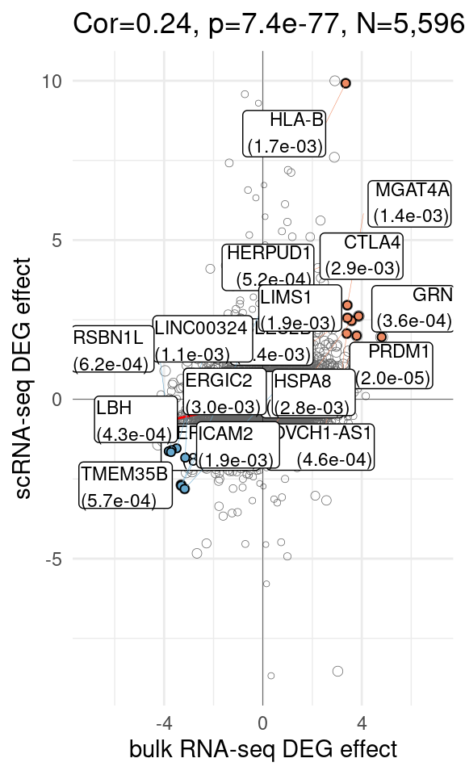

PDF

#### Memory Tconv genes

```r
.sc <- hc.ms.deg[celltype == "mTconv" &
                 sign(ADD) == sign(z) &
                 sign(ADC) == sign(z),]

.bulk <- bulk.mTconv.dt

.out <- plot.bulk.sc(.sc,
                     .bulk,
                     fdr.cutoff = .01,
                     qv.cutoff = .2,
                     n.top = 10)
```

#### Correlation 0.2 with p-value = 5.1e-63

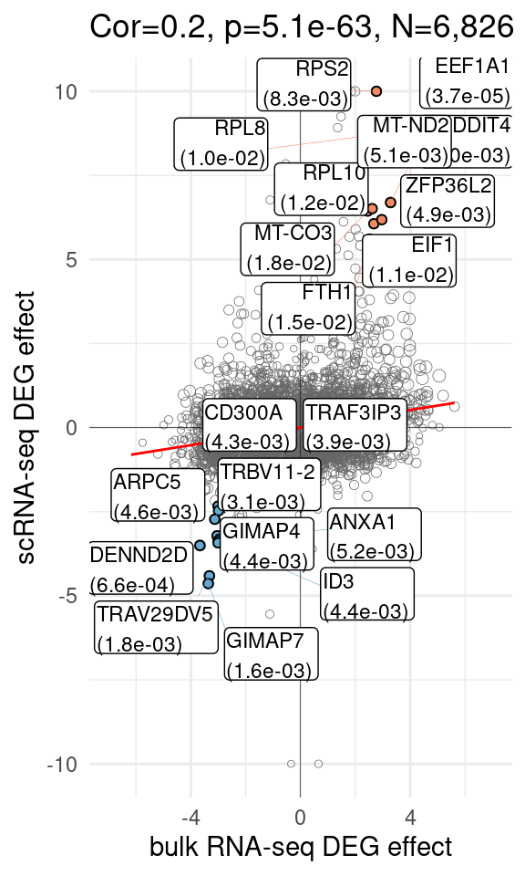

PDF

### Found 623 unique genes strongly perturbed by MS with FWER 5%

- Up-regulated: 494
- Down-regulated: 155
- Total pairs of genes and cell types: 47,008

```r
count.deg <- function(.dt, fwer.cutoff = .05) {
    .dt[fwer < fwer.cutoff &
        sign(ADD) == sign(ADE) &
        sign(ADC) == sign(ADE),
        .(n = .N),
        by = .(celltype,
               direction = if_else(z > 0, "up", "down"))
        ] %>%
        mutate(direction = factor(direction, c("up", "down"))) %>%
        group_by(celltype) %>%
        arrange(desc(direction)) %>%
        mutate(nc = cumsum(n)) %>%
        ungroup
}
```

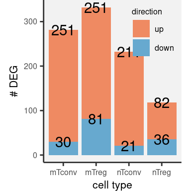

PDF

```r
show.each.gene <- function(g, .data, .stat, .cutoff = 0) {

    .dt.g <- na.omit(.data[gene == g]) %>% filter(tot > .cutoff)
    .stat.dt <- na.omit(.stat[gene == g]) %>% rename(total = tot)

    .dir <- .stat.dt[which.max(abs(.stat.dt$ADE)), .(ADE)] %>%
        unlist

    if(.dir > 0) {

        .dt <- .dt.g %>%
            left_join(.stat.dt, by = c("celltype", "gene")) %>%
            group_by(disease, celltype) %>%
            arrange(cfa) %>%
            mutate(j = 1:n()) %>%
            ungroup() %>%
            mutate(x = disease %&% "_" %&% j)

    } else {

        .dt <- .dt.g %>%
            left_join(.stat.dt, by = c("celltype", "gene")) %>%
            group_by(disease, celltype) %>%
            arrange(desc(cfa)) %>%
            mutate(j = 1:n()) %>%
            ungroup() %>%
            mutate(x = disease %&% "_" %&% j)

    }

    .dt <- .dt %>%
        mutate(.pv = if_else(is.na(pv), "1", num.sci(pv))) %>%
        mutate(.facet = celltype %&% "\n(" %&% .pv %&% ")") %>%
        mutate(ADD.z = ADD/ADD.se, ADC.z = ADC/ADC.se) %>%
        as.data.table

    .stat.dt <- .dt[, .(celltype,
                        ADE, ADE.se,
                        ADD, ADD.se,
                        ADC, ADC.se,
                        pv, .facet)] %>%
        unique

    .aes <- aes(x = x,
                y = cfa,
                ymin = cfa - 2 * cfa.sd,
                ymax = cfa + 2 * cfa.sd,
                fill = disease)

    .scale.y <- scale_y_continuous(labels = function(x) num.round(exp(x)))

    p1 <-
        .gg.plot(.dt, .aes) +
        theme(legend.position = "top") +
        facet_wrap(~.facet, nrow = 1, scales="free") +
        .scale.y +
        theme(axis.ticks.x = element_blank()) +
        theme(axis.text.x = element_blank()) +
        theme(axis.title.x = element_blank()) +
        geom_hline(yintercept = 0, linewidth = 1, colour = "gray") +
        geom_hline(data = .stat.dt, aes(yintercept = ADE), linewidth = 1, colour = "#F8766D") +
        geom_linerange(linewidth = .2) +
        geom_point(aes(size = tot), pch = 21, stroke = .2) +
        scale_size_continuous("total", range=c(0, 2.5)) +
        scale_fill_manual(values = c("gray90","#F8766D")) +
        xlab("") + ylab("fold change") + ggtitle(g)

    .temp.1 <- .stat.dt %>%
        dplyr::select(celltype, pv, ADE, ADD, ADC) %>%
        mutate(ADC = - ADC) %>%                  # flip the effect
        melt(id.vars=c("celltype", "pv"), value.name = "mu")

    .temp.2 <- .stat.dt %>%
        dplyr::select(celltype, ADE.se, ADD.se, ADC.se) %>%
        melt(id.vars="celltype", value.name = "se") %>%
        mutate(variable = str_remove(variable, ".se"))

    .temp <- left_join(.temp.1, .temp.2, by = c("celltype", "variable"))

    .aes <- aes(x = variable,
                y = mu,
                ymin = mu - 3 * se,
                ymax = mu + 3 * se)

    p2 <-
        .gg.plot(.temp, .aes) +
        theme(axis.text.x = element_text(angle=90, hjust = 1, vjust= .5)) +
        facet_wrap(~celltype, nrow = 1, scales="free") +
        .scale.y + ylab("fold change") + xlab("") +
        geom_hline(yintercept = 0, lty = 2, linewidth = .5, colour = "black") +
        geom_linerange(linewidth = .2) +
        geom_point(aes(fill = variable, stroke = .2, size = -log10(pv)), pch = 21) +
        scale_fill_brewer(palette = "Greens", guide="none") +
        scale_size_continuous("p-value", range=c(.5, 2.5), breaks=seq(0, 10, 2), labels = function(x) 10^(-x))

    plt <- (p1 / p2) + patchwork::plot_layout(heights = c(4,2))
    return(plt)
}
```

```r
.bulk.genes <-
    rbind(bulk.mTreg.dt[bulk.qv < .2, .(gene)],
          bulk.mTconv.dt[bulk.qv < .2, .(gene)]) %>%
    unique() %>%
    unlist()

.genes.show <-
    hc.ms.deg[fwer < 0.05 &
              gene %in% .bulk.genes &
              sign(ADD) == sign(ADE) &
              sign(ADC) == sign(ADE)] %>%
    select(gene) %>%
    unique %>%
    unlist %>%
    as.character
```

ACAT1 ACTG1 ANXA1 ANXA2 AREG ARPC5 ATF7IP2 BCAS2 BCL3 BIRC3 BTF3 BTG1 C14orf119 CCR4 CCT5 CD300A CEBPD CIRBP CLEC11A CLEC2B CLIC1 COX4I1 CRIP1 CTLA4 DDIT4 DDX17 DENND2D DUSP4 EEF1A1 EEF1B2 EEF1D EEF2 EIF1 EIF3E EIF3F EIF3L EMC6 EMP3 ETHE1 ETS1 FOSL2 FOXP1 FTH1 G3BP2 GADD45A GIMAP1 GIMAP4 GIMAP7 GRN GTSF1 GYPC H3F3B HERPUD1 HLA-B HMGB2 HNRNPA1 HP1BP3 HSDL2 HSPA8 HSPD1 ICAM2 ID3 IL7R IMPDH2 IRF1 KLF3 LBH LEPROTL1 LIMD2 LIMS1 LINC01089 M6PR MAP3K8 MGAT4A MRPL52 MT-CO3 MT-ND2 MT2A MYL12A NACA NINJ1 NPM1 NQO2 ODC1 OSER1 OSGEP OSM OVCH1-AS1 PABPC1 PASK PCBP2 PCGF5 PDE4B PELI1 PFDN4 PHGDH PIK3IP1 PLEK PLP2 PNP PRDM1 PRDX3 PRF1 PTGER2 PTMA PTPRCAP PYGO2 RAC2 RACK1 RGCC RGS14 RNF145 RNMT RPL10 RPL12 RPL14 RPL15 RPL19 RPL21 RPL23A RPL3 RPL4 RPL5 RPL7 RPL7A RPL8 RPL9 RPLP0 RPS2 RPS3 RPS4X RPS6 RPS7 RPSA RSL24D1 SARAF SBDS SETD7 SGK1 SLC25A6 SOCS1 SPOCK2 SRGN STX11 TMEM106B TNFAIP8 TNFAIP8L2 TRAC TRAF3IP3 TRAV21 TRAV27 TRAV29DV5 TRAV8-2 TRAV9-2 TRBV11-2 TRBV12-3 TRBV24-1 TUBA1B TUBB XBP1 YBX1 YWHAB YWHAQ ZFP36L2 ZFP90 ZNF394